# Технологический практикум (практикум на ЭВМ)

## 7. Продемонстрировать пример анализа данных с помощью графиков квантилей, метода огибающих, а также стандартных процедур проверки гипотез о нормальности. Рассмотреть выборки малого и умеренного объемов.

Начнем с выборки малого объема. Для этого я воспользуюсь новым датасетом, содержащем информацию о 77 видах хлопьев (https://www.kaggle.com/datasets/crawford/80-cereals).

Поля в наборе данных:

1. Name: Название хлопьев
2. mfr: Производитель хлопьев

2.1. A = American Home Food Products;

2.2. G = General Mills;

2.3. K = Kelloggs;

2.4. N = Nabisco;

2.5. P = Post;

2.6. Q = Quaker Oats;

2.7. R = Ralston Purina

3. type: 3.1. cold = холодные хлопья

3.2. hot = горячие хлопья

4. calories: калорийность на порцию
5. protein: граммы белка
6. fat: граммы жира
7. sodium: миллиграммы натрия
8. fiber: граммы пищевых волокон
9. carbo: граммы сложных углеводов
10. sugars: граммы сахара
11. potass: миллиграммы калия
12. vitamins: витамины и минералы — 0, 25 или 100, указывающие типичный процент от рекомендуемой нормы FDA
13. shelf: номер полки для демонстрации (1, 2 или 3, считая от пола)
14. weight: вес одной порции в унциях
15. cups: количество чашек в одной порции
16. rating: рейтинг хлопьев

Изучим, как распределены различные характеристики хлопьев в этом датасете.

Для начала загрузим датасет в окружение.

```python
cereal = pd.read_csv("D:\\Artyom\\ВМК\\5 семестр\\Практикум\\Cereal.csv")
cereal.head()
```

|  | name | mfr | type | calories | protein | fat | sodium | fiber | carbo | sugars | potass | vitamins | shelf | weight | cups | rating |
| --- | --- | --- | --- | --- | --- | --- | --- | --- | --- | --- | --- | --- | --- | --- | --- | --- |
| 0 | 100% Bran | N | C | 70 | 4 | 1 | 130 | 10.0 | 5.0 | 6 | 280 | 25 | 3 | 1.0 | 0.33 | 68.402973 |
| 1 | 100% Natural Bran | Q | C | 120 | 3 | 5 | 15 | 2.0 | 8.0 | 8 | 135 | 0 | 3 | 1.0 | 1.00 | 33.983679 |
| 2 | All-Bran | K | C | 70 | 4 | 1 | 260 | 9.0 | 7.0 | 5 | 320 | 25 | 3 | 1.0 | 0.33 | 59.425505 |
| 3 | All-Bran with Extra Fiber | K | C | 50 | 4 | 0 | 140 | 14.0 | 8.0 | 0 | 330 | 25 | 3 | 1.0 | 0.50 | 93.704912 |
| 4 | Almond Delight | R | C | 110 | 2 | 2 | 200 | 1.0 | 14.0 | 8 | -1 | 25 | 3 | 1.0 | 0.75 | 34.384843 |

```python
cereal.describe()
```

[output not shown]

Для анализа выборки умеренного объема я возьму данные из датасета sleep - LightExposureHours.

### Анализ данных с помощью графиков квантилей

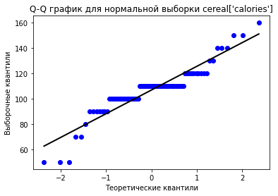

```python
qqgraph(cereal['calories'], data_name="cereal['calories']", point_color="blue")
```

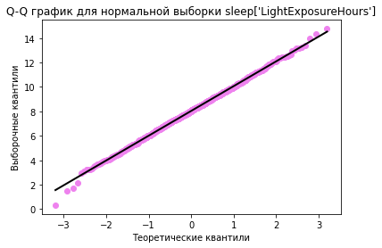

```python
qqgraph(sleep['LightExposureHours'], data_name="sleep['LightExposureHours']", point_color="violet")
```

### Анализ с помощью метода огибающих

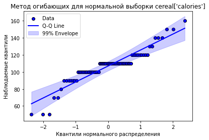

```python
my_envelope(cereal['calories'], data_name="cereal['calories']", color="blue", confidence=0.99)
```

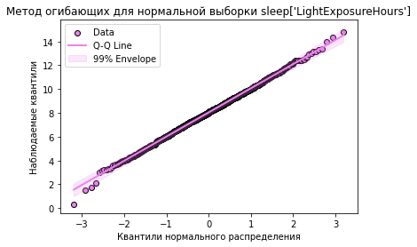

```python
my_envelope(sleep['LightExposureHours'], data_name="sleep['LightExposureHours']", color="violet", confidence=0.99)
```

### Стандартные процедуры проверки гипотез о нормальности

1. Критерий Колмогорова-Смирнова

Проведем тест Колмогорова-Смирнова для калорий.

```python
from scipy.stats import kstest

print("cereal['calories'] ", kstest(cereal['calories'], 'norm', args=(
    np.mean(cereal['calories']),
    np.std(cereal['calories'])
)))
```

```
cereal['calories']  KstestResult(statistic=0.20227281151401433, pvalue=0.003076388008321662, statistic_location=110, statistic_sign=1)
```

И сразу сталкиваемся с проблемой: для корректного проведения данного теста все значения в выборке должны быть уникальными. Добавим нормальный шум к элементам этой выборки и проведем тест для зашумленных данных.

```python
np.random.seed(0)
cereal['calories_noisy'] = cereal['calories'] + np.random.normal(0, 1e-6, len(cereal['calories']))
print(kstest(cereal['calories_noisy'], 'norm', args=(np.mean(cereal['calories_noisy']), np.std(cereal['calories_noisy']))))
```

```
KstestResult(statistic=0.20227276436439134, pvalue=0.003076397287864907, statistic_location=110.00000226975462, statistic_sign=1)
```

Данные о калориях не распределены нормально, поскольку тест выдал `p-value < 0.05`. Проведем исследование для LightExposureHours.

```python
print("sleep['LightExposureHours']: ", kstest(sleep['LightExposureHours'], 'norm', args=(np.mean(sleep['LightExposureHours']), np.std(sleep['LightExposureHours']))))
```

```
sleep['LightExposureHours']:  KstestResult(statistic=0.012797366603140958, pvalue=0.9960552040050962, statistic_location=7.217950666268847, statistic_sign=-1)
```

Данные о часах воздействия света в течение дня распределены нормально (проверял выше), поскольку тест выдал `p-value > 0.05`.

2. Критерий Шапиро-Уилка

```python
from scipy.stats import shapiro

print("cereal['calories']: ", shapiro(cereal['calories']))
print("sleep['LightExposureHours']: ", shapiro(sleep['LightExposureHours']))
```

[output not shown]

Данные о калориях не распределены нормально, поскольку тест выдал `p-value < 0.05`. Данные о часах воздействия света в течение дня распределены нормально, поскольку тест выдал `p-value > 0.05`.

3. Критерий Андерсона-Дарлинга

```python
from scipy.stats import anderson

print("cereal['calories']: ", anderson(cereal['calories']))
print("sleep['LightExposureHours']: ", anderson(sleep['LightExposureHours']))
```

```
cereal['calories']:  AndersonResult(statistic=3.3983617713279273, critical_values=array([0.55 , 0.626, 0.751, 0.876, 1.042]), significance_level=array([15. , 10. ,  5. ,  2.5,  1. ]), fit_result=  params: FitParams(loc=106.88311688311688, scale=19.484119056820845)
 success: True
 message: '`anderson` successfully fit the distribution to the data.')
sleep['LightExposureHours']:  AndersonResult(statistic=0.14420950438375257, critical_values=array([0.574, 0.653, 0.784, 0.914, 1.088]), significance_level=array([15. , 10. ,  5. ,  2.5,  1. ]), fit_result=  params: FitParams(loc=8.036683533832436, scale=2.0233708746008334)
 success: True
 message: '`anderson` successfully fit the distribution to the data.')
```

Данные о калориях не распределены нормально, поскольку тест выдал `p-value < 0.05`. Данные о часах воздействия света в течение дня распределены нормально, поскольку тест выдал `p-value > 0.05`.

4. Критерий Крамера фон Мизеса

```python
from scipy.stats import cramervonmises

cereal_calories = cereal['calories']
sleep_light_exposure = sleep['LightExposureHours']

mean_cereal = np.mean(cereal_calories)
std_cereal = np.std(cereal_calories)

mean_sleep = np.mean(sleep_light_exposure)
std_sleep = np.std(sleep_light_exposure)

print(cramervonmises(cereal_calories, 'norm', args=(mean_cereal, std_cereal)))
print(cramervonmises(sleep_light_exposure, 'norm', args=(mean_sleep, std_sleep)))
```

```
CramerVonMisesResult(statistic=0.6526996596289393, pvalue=0.016365234031646247)
CramerVonMisesResult(statistic=0.021759872399718567, pvalue=0.9950563512105673)
```

Данные о калориях не распределены нормально, поскольку тест выдал `p-value < 0.05`. Данные о часах воздействия света в течение дня распределены нормально, поскольку тест выдал `p-value > 0.05`.

5. Критерий Колмогорова-Смирнова в модификации Лиллиефорса и Шапиро-Франсия

```python
from statsmodels.stats.diagnostic import lilliefors

print("cereal['calories']: ", lilliefors(cereal['calories'], 'norm'))
print("sleep['LightExposureHours']: ", lilliefors(sleep['LightExposureHours'], 'norm'))
```

```
cereal['calories']:  (0.20268594574766619, 0.0009999999999998899)
sleep['LightExposureHours']:  (0.012871788534215722, 0.9740677749795653)
```

Данные о калориях не распределены нормально, поскольку тест выдал `p-value < 0.05`. Данные о часах воздействия света в течение дня распределены нормально, поскольку тест выдал `p-value > 0.05`.

6. Критерий Шапиро-Франсия

```python
from sfrancia import shapiroFrancia


print("cereal['calories']: ", shapiroFrancia(cereal['calories']))
print("sleep['LightExposureHours']: ", shapiroFrancia(sleep['LightExposureHours']))
```

```
cereal['calories']:  {'method': 'Shapiro-Francia normality test', 'statistics W': 0.8882546426607151, 'statistics z': 4.092206547315917, 'p-value': 2.1364389741374462e-05}
sleep['LightExposureHours']:  {'method': 'Shapiro-Francia normality test', 'statistics W': 0.9989791452456528, 'statistics z': -0.8718693700261626, 'p-value': 0.8083601774069678}
```

Данные о калориях не распределены нормально, поскольку тест выдал `p-value < 0.05`. Данные о часах воздействия света в течение дня распределены нормально, поскольку тест выдал `p-value > 0.05`.

# 8. Продемонстрировать применение для проверки различных гипотез и различных доверительных уровней (0.9, 0.95, 0.99) следующих критериев:

Для проверки гипотез возьмем новый интересный датасет -- зависимость уровня счастья в странах от различных показателей.

```python
happiness = pd.read_csv('happiness.csv')
happiness.head(3)
```

|  | Country name | Regional indicator | Ladder score | Standard error of ladder score | upperwhisker | lowerwhisker | Logged GDP per capita | Social support | Healthy life expectancy | Freedom to make life choices | Generosity | Perceptions of corruption | Ladder score in Dystopia | Explained by: Log GDP per capita | Explained by: Social support | Explained by: Healthy life expectancy | Explained by: Freedom to make life choices | Explained by: Generosity | Explained by: Perceptions of corruption | Dystopia + residual |
| --- | --- | --- | --- | --- | --- | --- | --- | --- | --- | --- | --- | --- | --- | --- | --- | --- | --- | --- | --- | --- |
| 0 | Finland | Western Europe | 7.842 | 0.032 | 7.904 | 7.780 | 10.775 | 0.954 | 72.0 | 0.949 | -0.098 | 0.186 | 2.43 | 1.446 | 1.106 | 0.741 | 0.691 | 0.124 | 0.481 | 3.253 |
| 1 | Denmark | Western Europe | 7.620 | 0.035 | 7.687 | 7.552 | 10.933 | 0.954 | 72.7 | 0.946 | 0.030 | 0.179 | 2.43 | 1.502 | 1.108 | 0.763 | 0.686 | 0.208 | 0.485 | 2.868 |
| 2 | Switzerland | Western Europe | 7.571 | 0.036 | 7.643 | 7.500 | 11.117 | 0.942 | 74.4 | 0.919 | 0.025 | 0.292 | 2.43 | 1.566 | 1.079 | 0.816 | 0.653 | 0.204 | 0.413 | 2.839 |

Переименуем некоторые столбцы для удобства

```python
happiness.rename(columns={
    "Ladder score": "happiness_score",
    "Regional indicator": "region",
    "Standard error of ladder score": "std happiness_score",
    "Logged GDP per capita": "gdp",
    "Social support": "social_support",
    "Freedom to make life choices": "freedom",
    "Generosity": "generosity",
    "Perceptions of corruption": "corruption_perceptions",
    "Healthy life expectancy": "life_expectancy"
}, inplace=True)
happiness.drop(happiness.columns[12:], axis=1, inplace=True)
happiness.drop(["std happiness_score", "upperwhisker", "lowerwhisker"], axis=1, inplace=True)
happiness.head(3)
```

|  | Country name | region | happiness_score | gdp | social_support | life_expectancy | freedom | generosity | corruption_perceptions |
| --- | --- | --- | --- | --- | --- | --- | --- | --- | --- |
| 0 | Finland | Western Europe | 7.842 | 10.775 | 0.954 | 72.0 | 0.949 | -0.098 | 0.186 |
| 1 | Denmark | Western Europe | 7.620 | 10.933 | 0.954 | 72.7 | 0.946 | 0.030 | 0.179 |
| 2 | Switzerland | Western Europe | 7.571 | 11.117 | 0.942 | 74.4 | 0.919 | 0.025 | 0.292 |

## a. Стьюдента, включая односторонние варианты, когда проверяемая нулевая гипотеза заключается в том, что одно из сравниваемых средних значений больше (или меньше) другого. Реализовать оценку мощности критериев при заданном объеме выборки или определения объема выборки для достижения заданной мощности;

### 1. Одновыборочный критерий Стьюдента.

Пусть дана выборка $ x^n = (x_1, \dots, x_n), \; x_i \in \mathbb{R}; $

Обозначим через $\mu$ и $ \sigma^2 $ математическое ожидание и дисперсию выборки соответственно.

**Дополнительное предположение**: выборка $ x^n $ является нормальной.

Нулевая гипотеза $ H_0: \mu = \mu_0,$ где $\mu_0$ - некоторое заданное число.

Альтернативные гипотезы:

$ H_1: \mu \neq \mu_0 $ (two-sided)

$ H_1': \mu > \mu_0 $ (greater)

$ H_1'': \mu < \mu_0 $ (less)

Проверим выборку `happiness_score` на нормальность.

```python
shapiro(happiness['happiness_score'])
```

```
ShapiroResult(statistic=0.9912537209520474, pvalue=0.4893410649623995)
```

`p-value > 0.05`, поэтому уровень счастья распределен нормально.

Проверим, равен ли уровень счастья 5.9 на разных уровнях значимости `alpha = 0.90`, `alpha = 0.95`, `alpha = 0.99`.

```python
happiness['happiness_score'].mean()
```

```
5.532838926174497
```

#### 1. Двусторонний критерий Стьюдента

```python
from pingouin import ttest
mu = 5.9
```

```python
ttest(happiness['happiness_score'], mu, alternative = 'two-sided', confidence=0.9)
```

|  | T | dof | alternative | p-val | CI90% | cohen-d | BF10 | power |
| --- | --- | --- | --- | --- | --- | --- | --- | --- |
| T-test | -4.173269 | 148 | two-sided | 0.000051 | [5.387214401072244, 5.67846345127675] | 0.341888 | 296.919 | 0.985595 |

```python
ttest(happiness['happiness_score'], mu, alternative = 'two-sided', confidence=0.95)
```

|  | T | dof | alternative | p-val | CI95% | cohen-d | BF10 | power |
| --- | --- | --- | --- | --- | --- | --- | --- | --- |
| T-test | -4.173269 | 148 | two-sided | 0.000051 | [5.36, 5.71] | 0.341888 | 296.919 | 0.985595 |

```python
ttest(happiness['happiness_score'], mu, alternative = 'two-sided', confidence=0.99)
```

|  | T | dof | alternative | p-val | CI99% | cohen-d | BF10 | power |
| --- | --- | --- | --- | --- | --- | --- | --- | --- |
| T-test | -4.173269 | 148 | two-sided | 0.000051 | [5.303260924288216, 5.762416928060778] | 0.341888 | 296.919 | 0.985595 |

#### 2.1 Односторонние критерии Стьюдента. Greater.

```python
ttest(happiness['happiness_score'], mu, alternative = 'greater', confidence=0.9)
```

|  | T | dof | alternative | p-val | CI90% | cohen-d | BF10 | power |
| --- | --- | --- | --- | --- | --- | --- | --- | --- |
| T-test | -4.173269 | 148 | greater | 0.999974 | [5.419583428977035, inf] | 0.341888 | 0.002 | 3.330846e-09 |

```python
ttest(happiness['happiness_score'], mu, alternative = 'greater', confidence=0.95)
```

|  | T | dof | alternative | p-val | CI95% | cohen-d | BF10 | power |
| --- | --- | --- | --- | --- | --- | --- | --- | --- |
| T-test | -4.173269 | 148 | greater | 0.999974 | [5.39, inf] | 0.341888 | 0.002 | 3.330846e-09 |

```python
ttest(happiness['happiness_score'], mu, alternative = 'greater', confidence=0.99)
```

|  | T | dof | alternative | p-val | CI99% | cohen-d | BF10 | power |
| --- | --- | --- | --- | --- | --- | --- | --- | --- |
| T-test | -4.173269 | 148 | greater | 0.999974 | [5.325928671365098, inf] | 0.341888 | 0.002 | 3.330846e-09 |

#### 2.2 Односторонние критерии Стьюдента. Less.

```python
ttest(happiness['happiness_score'], mu, alternative = 'less', confidence=0.9)
```

|  | T | dof | alternative | p-val | CI90% | cohen-d | BF10 | power |
| --- | --- | --- | --- | --- | --- | --- | --- | --- |
| T-test | -4.173269 | 148 | less | 0.000026 | [-inf, 5.646094423371959] | 0.341888 | 593.838 | 0.99395 |

```python
ttest(happiness['happiness_score'], mu, alternative = 'less', confidence=0.95)
```

|  | T | dof | alternative | p-val | CI95% | cohen-d | BF10 | power |
| --- | --- | --- | --- | --- | --- | --- | --- | --- |
| T-test | -4.173269 | 148 | less | 0.000026 | [-inf, 5.68] | 0.341888 | 593.838 | 0.99395 |

```python
ttest(happiness['happiness_score'], mu, alternative = 'less', confidence=0.99)
```

|  | T | dof | alternative | p-val | CI99% | cohen-d | BF10 | power |
| --- | --- | --- | --- | --- | --- | --- | --- | --- |
| T-test | -4.173269 | 148 | less | 0.000026 | [-inf, 5.739749180983896] | 0.341888 | 593.838 | 0.99395 |

#### 3. Определение объема выборки для достижения заданной мощности

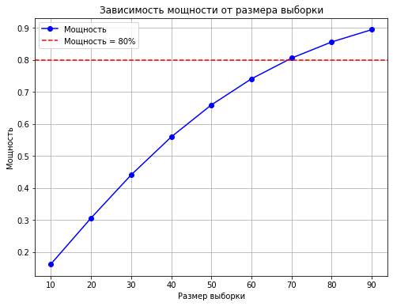

```python
from statsmodels.stats.power import TTestPower

mu_0 = 5.9
sample_mean = np.mean(happiness['happiness_score'])
sample_sd = np.std(happiness['happiness_score'], ddof=1)
delta = abs(sample_mean - mu_0)

power_analysis = TTestPower()
n_values = np.arange(10, 100, 10)
effect_size = delta / sample_sd
power_values = [power_analysis.power(effect_size=effect_size, nobs=n_iter, alpha=0.05, alternative='two-sided') for n_iter in n_values]


plt.figure(figsize=(8, 6))
plt.plot(n_values, power_values, marker='o', color='blue', label='Мощность')
plt.axhline(y=0.8, color='red', linestyle='--', label='Мощность = 80%')
plt.title("Зависимость мощности от размера выборки")
plt.xlabel("Размер выборки")
plt.ylabel("Мощность")
plt.grid()
plt.legend()
plt.show()
```

Видим, что для достижения мощности 0.8 при уровне значимости 0.05 размер выборки должен быть $\approx $ 70.

### 2. Двухвыборочный критерий Стьюдента

Пусть даны две независимые выборки $ x^n = (x_1, \dots, x_n), \; x_i \in \mathbb{R}; \quad y^m = (y_1, \dots, y_m), \; y_i \in \mathbb{R}. $

Обозначим через $ \mu_1 $ и $ \mu_2 $ математические ожидания выборок $ x^n $ и $ y^m$.

**Дополнительное предположение**: выборки $ x^n $ и $ y^m $ являются нормальными.

Нулевая гипотеза $ H_0: \mu_1 = \mu_2 $

Альтернативные гипотезы:

$ H_1: \mu_1 \neq \mu_2 $ (two-sided)

$ H_1': \mu_1 > \mu_2 $ (greater)

$ H_1'': \mu_1 < \mu_2 $ (less)

Сравним математические ожидания уровня счастья в странах Европы и Азии.

```python
europe_table = happiness[happiness.region.isin(['Western Europe', 'Central and Eastern Europe', 'Commonwealth of Independent States'])]
asia_table = happiness[happiness.region.isin(['East Asia', 'Southeast Asia', 'South Asia'])]

print(europe_table['happiness_score'].mean(), asia_table['happiness_score'].mean())
```

```
6.251160000000001 5.210136363636364
```

#### 1. Двухсторонний критерий Стьюдента

```python
ttest(europe_table['happiness_score'], asia_table['happiness_score'], alternative = 'two-sided', confidence=0.9)
```

|  | T | dof | alternative | p-val | CI90% | cohen-d | BF10 | power |
| --- | --- | --- | --- | --- | --- | --- | --- | --- |
| T-test | 4.707294 | 37.299201 | two-sided | 0.000034 | [0.6679976864688363, 1.4140495862584384] | 1.245067 | 1380.804 | 0.997736 |

```python
ttest(europe_table['happiness_score'], asia_table['happiness_score'], alternative = 'two-sided', confidence=0.95)
```

|  | T | dof | alternative | p-val | CI95% | cohen-d | BF10 | power |
| --- | --- | --- | --- | --- | --- | --- | --- | --- |
| T-test | 4.707294 | 37.299201 | two-sided | 0.000034 | [0.59, 1.49] | 1.245067 | 1380.804 | 0.997736 |

```python
ttest(europe_table['happiness_score'], asia_table['happiness_score'], alternative = 'two-sided', confidence=0.99)
```

|  | T | dof | alternative | p-val | CI99% | cohen-d | BF10 | power |
| --- | --- | --- | --- | --- | --- | --- | --- | --- |
| T-test | 4.707294 | 37.299201 | two-sided | 0.000034 | [0.4407675841218777, 1.6412796886053969] | 1.245067 | 1380.804 | 0.997736 |

#### 2.1 Односторонние критерии Стьюдента. Greater.

```python
ttest(europe_table['happiness_score'], asia_table['happiness_score'], alternative = 'greater', confidence=0.9)
```

|  | T | dof | alternative | p-val | CI90% | cohen-d | BF10 | power |
| --- | --- | --- | --- | --- | --- | --- | --- | --- |
| T-test | 4.707294 | 37.299201 | greater | 0.000017 | [0.7524956152125972, inf] | 1.245067 | 2761.608 | 0.999248 |

```python
ttest(europe_table['happiness_score'], asia_table['happiness_score'], alternative = 'greater', confidence=0.95)
```

|  | T | dof | alternative | p-val | CI95% | cohen-d | BF10 | power |
| --- | --- | --- | --- | --- | --- | --- | --- | --- |
| T-test | 4.707294 | 37.299201 | greater | 0.000017 | [0.67, inf] | 1.245067 | 2761.608 | 0.999248 |

```python
ttest(europe_table['happiness_score'], asia_table['happiness_score'], alternative = 'greater', confidence=0.99)
```

|  | T | dof | alternative | p-val | CI99% | cohen-d | BF10 | power |
| --- | --- | --- | --- | --- | --- | --- | --- | --- |
| T-test | 4.707294 | 37.299201 | greater | 0.000017 | [0.5035004057196879, inf] | 1.245067 | 2761.608 | 0.999248 |

#### 2.2 Односторонние критерии Стьюдента. Less.

```python
ttest(europe_table['happiness_score'], asia_table['happiness_score'], alternative = 'less', confidence=0.9)
```

|  | T | dof | alternative | p-val | CI90% | cohen-d | BF10 | power |
| --- | --- | --- | --- | --- | --- | --- | --- | --- |
| T-test | 4.707294 | 37.299201 | less | 0.999983 | [-inf, 1.3295516575146775] | 1.245067 | 0.0 | 5.048084e-11 |

```python
ttest(europe_table['happiness_score'], asia_table['happiness_score'], alternative = 'less', confidence=0.95)
```

|  | T | dof | alternative | p-val | CI95% | cohen-d | BF10 | power |
| --- | --- | --- | --- | --- | --- | --- | --- | --- |
| T-test | 4.707294 | 37.299201 | less | 0.999983 | [-inf, 1.41] | 1.245067 | 0.0 | 5.048084e-11 |

```python
ttest(europe_table['happiness_score'], asia_table['happiness_score'], alternative = 'less', confidence=0.99)
```

|  | T | dof | alternative | p-val | CI99% | cohen-d | BF10 | power |
| --- | --- | --- | --- | --- | --- | --- | --- | --- |
| T-test | 4.707294 | 37.299201 | less | 0.999983 | [-inf, 1.5785468670075868] | 1.245067 | 0.0 | 5.048084e-11 |

### b. Ранговый критерий Уилкоксона-Манна-Уитни

Пусть даны две независимые выборки $ x^n = (x_1, \dots, x_n), \; x_i \in \mathbb{R}; \quad y^m = (y_1, \dots, y_m), \; y_i \in \mathbb{R}. $

Обозначим через $ \mu_1 $ и $ \mu_2 $ математические ожидания выборок $ x^n $ и $ y^m$.

Нулевая гипотеза $ H_0: \mu_1 = \mu_2 $

Альтернативные гипотезы:

$ H_1: \mu_1 \neq \mu_2 $ (two-sided)

$ H_1': \mu_1 > \mu_2 $ (greater)

$ H_1'': \mu_1 < \mu_2 $ (less)

Сравним социальную поддержку в странах Европы (`Western Europe`, `Central and Eastern Europe`) и в странах Африки (`Middle East and North Africa`, `Sub-Saharan Africa`)

```python
europe = happiness['social_support'][(happiness.region == 'Western Europe') | (happiness.region == 'Central and Eastern Europe')]
africa = happiness['social_support'][(happiness.region == 'Middle East and North Africa') | (happiness.region == 'Sub-Saharan Africa')]
```

```python
print(europe.mean(), africa.mean())
```

```
0.9023684210526316 0.7291132075471698
```

```python
print('EX = EY (two-sided):\t', stats.mannwhitneyu(africa, europe, alternative='two-sided'))
print('EX > EY (greater):\t', stats.mannwhitneyu(africa, europe, alternative='greater'))
print('EX < EY (less):\t\t', stats.mannwhitneyu(africa, europe, alternative='less'))
```

```
EX = EY (two-sided):	 MannwhitneyuResult(statistic=138.0, pvalue=2.7501435122783994e-12)
EX > EY (greater):	 MannwhitneyuResult(statistic=138.0, pvalue=0.9999999999987016)
EX < EY (less):		 MannwhitneyuResult(statistic=138.0, pvalue=1.3750717561391997e-12)
```

### c. Проверка гипотез об однородности дисперсий

#### 1. Критерий Фишера

Пусть даны две выборки $ x^n = (x_1, \dots, x_n), \; x_i \in \mathbb{R}; \quad y^m = (y_1, \dots, y_m), \; y_i \in \mathbb{R}. $

Обозначим через $ \sigma_1^2 $ и $ \sigma_2^2 $ дисперсии выборок $ x^n $ и $ y^m$. **Дополнительное предположение**: выборки $ x^n $ и $ y^m $ являются нормальными.

Нулевая гипотеза $ H_0: \sigma_1^2 = \sigma_2^2 $

Альтернативные гипотезы:

$ H_1: \sigma_1^2 \neq \sigma_2^2 $ (two-sided)

$ H_1': \sigma_1^2 > \sigma_2^2 $ (greater)

$ H_1'': \sigma_1^2 < \sigma_2^2 $ (less)

Статистика критерия Фишера: $ F=\frac{s_1^2}{s_2^2}$, где $s_1^2, s_2^2$ - выборочные оценки дисперсий. Статистика F имеет распределение Фишера с n-1 и m-1 степенями свободы. Обычно в числителе ставится большая из двух сравниваемых дисперсий.

На языке Python нет реализованного критерия Фишера. Напишем его сами.

```python
def fisher_test(x, y, alternative='two_sided'):
    df1 = len(x) - 1
    df2 = len(y) - 1
    f = x.var(ddof=1) / y.var(ddof=1) # смещенная оценка дисперсии
    if alternative == 'greater':
        pvalue = 1 - stats.f.cdf(f, df1, df2)
    elif alternative == 'less':
        pvalue = stats.f.cdf(f, df1, df2)
    elif alternative == 'two_sided':
        pvalue =  min(2 * min(stats.f.cdf(f, df1, df2), 1 - stats.f.cdf(f, df1, df2)), 1)
    else:
        return ValueError("Альтернатива должна быть 'greater', 'less' или 'two-sided'")
    return pvalue
```

```python
print(sleep['LightExposureHours'].var(), sleep['MovementDuringSleep'].var())
```

```
4.094029696182942 0.9671823230179967
```

```python
print('two-sided (DX != DY): ', fisher_test(sleep['MovementDuringSleep'], sleep['LightExposureHours'], alternative='two_sided'))
print('greater (DX > DY): ', fisher_test(sleep['MovementDuringSleep'], sleep['LightExposureHours'], alternative='greater'))
print('less (DX < DY): ', fisher_test(sleep['MovementDuringSleep'], sleep['LightExposureHours'], alternative='less'))
```

```
two-sided (DX != DY):  2.0894199316191623e-106
greater (DX > DY):  1.0
less (DX < DY):  1.0447099658095812e-106
```

Дисперсия у `MovementDuringSleep` меньше, чем у `LightExposureHours`.

#### 2. Критерий Левене

Пусть даны две выборки $ x^n = (x_1, \dots, x_n), \; x_i \in \mathbb{R}; \quad y^m = (y_1, \dots, y_m), \; y_i \in \mathbb{R}. $

Обозначим через $ \sigma_1^2 $ и $ \sigma_2^2 $ дисперсии выборок $ x^n $ и $ y^m$.

Нулевая гипотеза $ H_0: \sigma_1^2 = \sigma_2^2 $

Альтернативная гипотеза: $ H_1: \sigma_1^2 \neq \sigma_2^2 $ (two-sided)

Сравним дисперсии показателя ВВП в странах Восточной и Центральной и Западной Европы.

```python
western = happiness['gdp'][happiness.region == 'Western Europe']
central_eastern = happiness['gdp'][happiness.region == 'Central and Eastern Europe']
print(western.std(), central_eastern.std())
```

```
0.30505624774082957 0.3961897384127073
```

```python
stats.levene(western, central_eastern, center='median')
```

```
LeveneResult(statistic=1.484699396604199, pvalue=0.2309658419374221)
```

`p-value > 0.05`, поэтому нет оснований отвергать гипотезу о равенстве дисперсий.

#### 3. Критерий Бартлетта

Пусть даны две выборки $ x^n = (x_1, \dots, x_n), \; x_i \in \mathbb{R}; \quad y^m = (y_1, \dots, y_m), \; y_i \in \mathbb{R}. $

Обозначим через $ \sigma_1^2 $ и $ \sigma_2^2 $ дисперсии выборок $ x^n $ и $ y^m$. **Дополнительное предположение**: выборки $ x^n $ и $ y^m $ являются нормальными.

Нулевая гипотеза $ H_0: \sigma_1^2 = \sigma_2^2 $

Альтернативная гипотеза: $ H_1: \sigma_1^2 \neq \sigma_2^2 $ (two-sided)

```python
print(sleep['MovementDuringSleep'].var(), sleep['LightExposureHours'].var())
```

```
0.9671823230179967 4.094029696182942
```

```python
stats.bartlett(sleep['MovementDuringSleep'], sleep['LightExposureHours'])
```

```
BartlettResult(statistic=480.03510865049805, pvalue=2.0994430927461594e-106)
```

Нулевая гипотеза отвергается. Дисперсии между группами значительно различаются.

#### 4. Критерий Флигнера-Килина

Пусть даны две выборки $ x^n = (x_1, \dots, x_n), \; x_i \in \mathbb{R}; \quad y^m = (y_1, \dots, y_m), \; y_i \in \mathbb{R}. $

Обозначим через $ \sigma_1^2 $ и $ \sigma_2^2 $ дисперсии выборок $ x^n $ и $ y^m$.

Нулевая гипотеза $ H_0: \sigma_1^2 = \sigma_2^2 $

Альтернативная гипотеза: $ H_1: \sigma_1^2 \neq \sigma_2^2 $ (two-sided)

```python
stats.fligner(western, central_eastern, center='median')
```

```
FlignerResult(statistic=1.1030312196968877, pvalue=0.2936018394177536)
```

`p-value > 0.05`, поэтому нет оснований отвергать гипотезу о равенстве дисперсий.

# 9. Исследовать корреляционные взаимосвязи в данных с помощью коэффициентов корреляции Пирсона, Спирмена и Кендалла.

```python
from scipy.stats import pearsonr
from scipy.stats import spearmanr
from scipy.stats import kendalltau
```

## 1. Корреляция Пирсона

Для вычисления коэффициентов корреляции Пирсона необходимы две нормально распределенных выборки.

```python
print(shapiro(sleep['LightExposureHours']))
print(shapiro(sleep['MovementDuringSleep']))
```

```
ShapiroResult(statistic=0.9992088621920048, pvalue=0.9574350739249153)
ShapiroResult(statistic=0.9987436654701078, pvalue=0.717817251078054)
```

```python
pearsonr(sleep['LightExposureHours'], sleep['MovementDuringSleep'])
```

```
PearsonRResult(statistic=0.0017388033647314349, pvalue=0.9562045404180117)
```

`p-value > 0.05`, это означает, что нет статистически значимой линейной зависимости между переменными.

## 2. Корреляция Спирмена

Для ненормально распределенных переменных, а также при наличии нелинейной связи между переменными следует использовать непараметрический коэффициент корреляции Спирмена.

```python
print(spearmanr(happiness['gdp'], happiness['happiness_score']))
```

```
SignificanceResult(statistic=0.8094072448957933, pvalue=8.406088246284765e-36)
```

Между переменными существует сильная и значимая положительная монотонная связь. Значение коэффициента Спирмена говорит о том, что с увеличением одной переменной другая также увеличивается, и эта связь достаточно надежна.

```python
print(spearmanr(happiness['gdp'], happiness['corruption_perceptions']))
```

```
SignificanceResult(statistic=-0.2769237188210104, pvalue=0.0006286773703761022)
```

## 3. Корреляция Кендалла

```python
print(kendalltau(happiness['gdp'], happiness['happiness_score']))
```

```
SignificanceResult(statistic=0.6165358979536958, pvalue=6.690763320614511e-29)
```

Между `gdp` и `happiness_score` существует сильная и значимая положительная монотонная связь.

```python
print(kendalltau(happiness['gdp'], happiness['corruption_perceptions']))
```

```
SignificanceResult(statistic=-0.1774772572316997, pvalue=0.0013326369113553004)
```

# 10. Продемонстрировать использование методов хи-квадрат, точного теста Фишера, теста МакНемара, Кохрана-Мантеля-Хензеля.

#### 1. Метод хи-квадрат

Метод хи-квадрат — это статистический метод для проверки независимости двух категориальных переменных (первая принимает k значений, вторая l значений) в таблице сопряженности k×l.

Пусть А - категориальная выборка, принимающая $n$ значений $a_1, a_2, \dots, a_n$, а B - категориальная выборка, принимающая $k$ значений $b_1, b_2, \dots, b_k$

|  | A = $a_1$ | A = $a_2$ | ... | A = $a_n$ |
| --- | --- | --- | --- | --- |
| B = $b_1$ | $f_{11}$ | $f_{12}$ | ... | $f_{1n}$ |
| B = $b_2$ | $f_{21}$ | $f_{22}$ | ... | $f_{2n}$ |
| ... | ... | ... | ... | ... |
| B = $b_k$ | $f_{k1}$ | $f_{k2}$ | ... | $f_{kn}$ |

Нулевая гипотеза $H_0: $ две переменные независимы

Найдем зависимость между уровнем ВВП и регионом проживания.

Разделим показания ВВП на три уровня: низкий (ниже 8.6), средний (от 8.6 до 10.1), высокий (более 10.1).

```python
bins = [0, 8.6, 10.1, 100]
labels = ['low', 'mediun', 'high']
happiness['gdp_category'] = pd.cut(happiness['gdp'], bins=bins, labels=labels, right=False)
```

Для удобства объединим некоторые регионы в бóльшие сущности:

1. `Europe`: `Western Europe` + `Central and Eastern Europe` + `Commonwealth of Independent States`
2. `America`: `North America and ANZ` + `Latin America and Caribbean`
3. `Asia`: `East Asia` + `Southeast Asia` + `South Asia`
4. `Africa`: `Sub-Saharan Africa` + `Middle East and North Africa`

```python
europe_table = happiness[happiness.region.isin(['Western Europe', 'Central and Eastern Europe', 'Commonwealth of Independent States'])]
america_table = happiness[happiness.region.isin(['North America and ANZ', 'Latin America and Caribbean'])]
asia_table = happiness[happiness.region.isin(['East Asia', 'Southeast Asia', 'South Asia'])]
africa_table = happiness[happiness.region.isin(['Sub-Saharan Africa', 'Middle East and North Africa'])]
europe_table.loc[:, 'region'] = 'Europe'
africa_table.loc[:, 'region'] = 'Africa'
asia_table.loc[:, 'region'] = 'Asia'
america_table.loc[:, 'region'] = 'America'
combined_table = pd.concat([europe_table, africa_table, america_table, asia_table], axis=0, ignore_index=True).sample(frac=1, random_state=42).reset_index(drop=True).loc[:, ['region', 'gdp_category']]

contingency_table = pd.crosstab(combined_table['region'], combined_table['gdp_category'])

print("Таблица сопряженности:")
print(contingency_table)
```

```
Таблица сопряженности:
gdp_category  low  mediun  high
region
Africa         32      15     6
America         1      18     5
Asia            6      10     6
Europe          2      15    33
```

```python
chi2, p, dof, expected = chi2_contingency(contingency_table)
print("Результаты теста хи-квадрат:")
print(f"χ²: {chi2}, p-значение: {p}, степени свободы: {dof}")
print("Ожидаемые частоты:")
print(expected)
```

```
Результаты теста хи-квадрат:
χ²: 71.33695169360263, p-значение: 2.1739840843314693e-13, степени свободы: 6
Ожидаемые частоты:
[[14.58389262 20.63087248 17.7852349 ]
 [ 6.60402685  9.34228188  8.05369128]
 [ 6.05369128  8.56375839  7.38255034]
 [13.75838926 19.46308725 16.77852349]]
```

Значение `p-value < 0.05`, значит между регионом и уровнем ВВП существует статистически значимая зависимость.

#### 2. Точный тест Фишера

Точный тест Фишера — это статистический метод для проверки независимости двух категориальных переменных в таблице сопряженности 2×2, особенно эффективный при малых выборках.

Пусть $A$, $B$ - две категориальные выборки, принимающие два значения: $a_1$, $a_2$ и $b_1$, $b_2$ соответственно.

|  | $A = a_1$ | $A = a_2$ |
| --- | --- | --- |
| $B = b_1$ | a | b |
| $B = b_2$ | c | c |

Нулевая гипотеза $H_0: $ две переменные независимы

Альтернативная гипотеза $H_1: $ между переменными A и B существует статистически значимая зависимость

Точный критерий Фишера рассчитывается по следующей формуле:

$$ P = \frac{(a+b)! \cdot (c+d)! \cdot (a+c)! \cdot (b+d)!}{a! \cdot b! \cdot c! \cdot d! \cdot n!} $$

```python
europe_table = happiness[(happiness.region == 'Western Europe') | (happiness.region == 'Central and Eastern Europe') ]
africa_table = happiness[(happiness.region == 'Middle East and North Africa') | (happiness.region == 'Sub-Saharan Africa') ]
europe_table.loc[:, 'region'] = 'Europe'
africa_table.loc[:, 'region'] = 'Africa'
combined_table = pd.concat([europe_table, africa_table], axis=0, ignore_index=True).sample(frac=1, random_state=42).reset_index(drop=True).loc[:, ['region', 'happiness_score']]
combined_table['happiness_category'] = combined_table.apply(lambda x: 'happy' if x['happiness_score'] > 6 else 'unhappy', axis=1)
contingency_table = pd.crosstab(combined_table['region'], combined_table['happiness_category'])

print("Таблица сопряженности:")
print(contingency_table)
```

[output not shown]

```python
from scipy.stats import fisher_exact
odds_ratio, p_value = fisher_exact(contingency_table)
print("Отношение шансов:", odds_ratio)
print("p-значение:", p_value)
```

```
Отношение шансов: 0.04559270516717325
p-значение: 1.6941705379426915e-09
```

Значение `p-value < 0.05`, значит между регионом и уровнем счастья существует статистически значимая зависимость.

#### 3. Тест МакНемара

Рассмотренный выше критерий хи-квадрат для анализа таблиц сопряженности размером 2х2 применим только в отношении независимых наблюдений. Если же учет какого-либо бинарного признака выполняется, например, на одних и тех же испытуемых, то вместо критерия хи-квадрат следует использовать **критерий Мак-Немара**. Он особенно полезен при анализе изменений в дихотомических переменных до и после воздействия или лечения.

|  | После: положительный | После: отрицательный | Итого |
| --- | --- | --- | --- |
| **До: положительный** | a | b | a+b |
| **До: отрицательный** | c | d | c+d |
| **Итого** | a+c | b+d | n |

Обозначения:

a: количество объектов с положительным результатом до и после воздействия;

b: количество объектов с положительным результатом до и отрицательным после;

c: количество объектов с отрицательным результатом до и положительным после;

d: количество объектов с отрицательным результатом до и после.

Нулевая гипотеза ($H_0$): пропорции положительных и отрицательных изменений равны, то есть b = c.

Альтернативная гипотеза ($H_1$): пропорции положительных и отрицательных изменений различаются, то есть $b \neq c$

Я нашел данные об уровне счастья за 2023 год. Сравним изменения. Пусть страна является счастливой, если `happiness_score > 6`.

```python
happiness2023 = pd.read_csv('happiness2023.csv')
happiness2023.rename(columns={
    "Ladder score": "happiness_score",
    "Regional indicator": "region",
    "Standard error of ladder score": "std happiness_score",
    "Logged GDP per capita": "gdp",
    "Social support": "social_support",
    "Freedom to make life choices": "freedom",
    "Generosity": "generosity",
    "Perceptions of corruption": "corruption_perceptions",
    "Healthy life expectancy": "life_expectancy"
}, inplace=True)
happiness2023.drop(happiness.columns[12:], axis=1, inplace=True)
happiness2023.drop(["std happiness_score", "upperwhisker", "lowerwhisker"], axis=1, inplace=True)
happiness2023 = happiness2023.iloc[:, :-8]

happiness2023.head(3)
```

|  | Country name | happiness_score | gdp | social_support | life_expectancy | freedom | generosity | corruption_perceptions |
| --- | --- | --- | --- | --- | --- | --- | --- | --- |
| 0 | Finland | 7.804 | 10.792 | 0.969 | 71.15 | 0.961 | -0.019 | 0.182 |
| 1 | Denmark | 7.586 | 10.962 | 0.954 | 71.25 | 0.934 | 0.134 | 0.196 |
| 2 | Iceland | 7.530 | 10.896 | 0.983 | 72.05 | 0.936 | 0.211 | 0.668 |

```python
happiness['happiness_category'] = happiness.apply(lambda x: 'happy' if x['happiness_score'] > 6 else 'unhappy', axis=1)
happiness2023['happiness_category'] = happiness2023.apply(lambda x: 'happy' if x['happiness_score'] > 6 else 'unhappy', axis=1)
sub_happiness = happiness.loc[:, ['Country name', 'happiness_category']]
sub_happiness2023 = happiness2023.loc[:, ['Country name', 'happiness_category']]
sub_happiness['year'] = 2021
sub_happiness2023['year'] = 2023

combined_data = pd.merge(
    sub_happiness[['Country name', 'happiness_category']],
    sub_happiness2023[['Country name', 'happiness_category']],
    on='Country name',
    suffixes=('_2021', '_2023')
)
```

```python
contingency_table = pd.crosstab(
    combined_data['happiness_category_2021'],
    combined_data['happiness_category_2023'],
    rownames=['2021'],
    colnames=['2023']
)

print("Таблица сопряженности 2×2:")
contingency_table
```

```
Таблица сопряженности 2×2:
```

| 2023 2021 | happy | unhappy |
| --- | --- | --- |
| happy | 47 | 3 |
| unhappy | 7 | 76 |

```python
from statsmodels.stats.contingency_tables import mcnemar

result = mcnemar(contingency_table, exact=False)
print(f'Статистика: {result.statistic}, p-значение: {result.pvalue}')
```

```
Статистика: 0.9, p-значение: 0.34278171114790873
```

`p-value > 0.05`, что свидетельствует о отсутствии статистически значимых изменениий между уровнем счастья в мире в 2021 и 2023 годах.

#### 4. Тест Кохрана-Мантеля-Хензеля

Тест Кохрана–Мантеля–Хензеля (КМХ) предназначен для анализа связи между двумя категориальными переменными при контроле влияния третьей категориальной переменной. Для этого создается K таблиц сопряженности 2x2, где K - количество значений в третьей категориальной переменной.

Нулевая гипотеза, проверяемая при помощи CMH-критерия, заключается в том, что между двумя анализируемыми качественными признаками нет никакой связи.

Изучим, как связаны уровень счастья `happiness_score` и социальная поддержка `social_support` в зависимости от региона (снова разделим все страны на четыре больших региона).

Итак, назовем страну *счастливой*, если `happiness_score > 6`.

Итак, назовем страну *страной с высоким уровнем социальной поддержки*, если `social_support > 0.77`.

```python
happiness['social_support_category'] = happiness.apply(lambda x: 'high' if x['social_support'] > 0.77 else 'low', axis=1)
happiness['happiness_category'] = happiness.apply(lambda x: 'happy' if x['happiness_score'] > 6 else 'unhappy', axis=1)

europe_table = happiness[happiness.region.isin(['Western Europe', 'Central and Eastern Europe', 'Commonwealth of Independent States'])]
america_table = happiness[happiness.region.isin(['North America and ANZ', 'Latin America and Caribbean'])]
asia_table = happiness[happiness.region.isin(['East Asia', 'Southeast Asia', 'South Asia'])]
africa_table = happiness[happiness.region.isin(['Sub-Saharan Africa', 'Middle East and North Africa'])]

europe_table.loc[:, 'region'] = 'Europe'
africa_table.loc[:, 'region'] = 'Africa'
asia_table.loc[:, 'region'] = 'Asia'
america_table.loc[:, 'region'] = 'America'
combined_table = pd.concat([europe_table, africa_table, america_table, asia_table], axis=0, ignore_index=True).sample(frac=1, random_state=42).reset_index(drop=True).loc[:, ['region', 'happiness_category', 'social_support_category']]
combined_table
```

|  | region | happiness_category | social_support_category |
| --- | --- | --- | --- |
| 0 | Africa | unhappy | low |
| 1 | Europe | happy | high |
| 2 | America | unhappy | high |
| 3 | Africa | unhappy | low |
| 4 | Africa | unhappy | low |
| ... | ... | ... | ... |
| 144 | Africa | unhappy | high |
| 145 | America | happy | high |
| 146 | Europe | happy | high |
| 147 | Africa | unhappy | low |
| 148 | Africa | unhappy | low |

149 rows × 3 columns

```python
from statsmodels.stats.contingency_tables import StratifiedTable

stratified_data = []
regions = combined_table['region'].unique()
for region in regions:
    subset = combined_table[combined_table['region'] == region]
    contingency_table = pd.crosstab(subset['happiness_category'], subset['social_support_category'])
    if contingency_table.shape == (2, 2):  # Только таблицы 2x2
        stratified_data.append(contingency_table.values)

stratified_data
```

```
[array([[ 6,  0],
        [13, 34]], dtype=int64),
 array([[30,  0],
        [18,  2]], dtype=int64),
 array([[13,  1],
        [ 9,  1]], dtype=int64),
 array([[ 2,  0],
        [14,  6]], dtype=int64)]
```

```python
StratifiedTable(stratified_data).summary()
```

|  | Estimate | LCB | UCB |
| --- | --- | --- | --- |
| Pooled odds | 16.363 | 2.130 | 125.704 |
| Pooled log odds | 2.795 | 0.756 | 4.834 |
| Pooled risk ratio | 1.307 |  |  |
|  | Statistic | P-value |  |
| Test of OR=1 | 12.965 | 0.000 |  |
| Test constant OR | 5.231 | 0.156 |  |
| Number of tables | 4 |  |  |
| Min n | 22 |  |  |
| Max n | 53 |  |  |
| Avg n | 37 |  |  |
| Total n | 149 |  |  |

```python
cmh_test = StratifiedTable(stratified_data)
result = cmh_test.test_null_odds()

print("Результаты теста Кохрана-Мантеля-Хензеля:")
print(f"Статистика: {result.statistic}")
print(f"p-значение: {result.pvalue}")
```

```
Результаты теста Кохрана-Мантеля-Хензеля:
Статистика: 12.964508202240273
p-значение: 0.00031745183824949397
```

Строка Test of OR=1 показывает результаты критерия Кохрана-Мантеля-Хензеля.

`p-value < 0.05`, значит связь между уровнем счастья и уровнем социальной поддержки есть.

# 11. Проверить наличие мультиколлинеарности в данных с помощью корреляционной матрицы и фактора инфляции дисперсии.

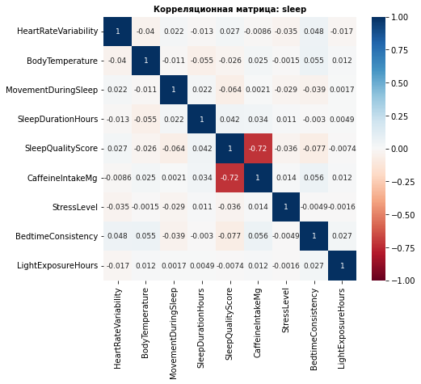

```python
fig = plt.figure(figsize=(7,6))

ax = sns.heatmap(sleep.corr(),
            vmin=-1, vmax=1, cmap='RdBu',
            annot = True,
            annot_kws={"fontsize":9})
plt.xticks(fontsize=10)
plt.yticks(fontsize=10)
cbar = ax.collections[0].colorbar
cbar.ax.tick_params(labelsize=10)
plt.title('Корреляционная матрица: sleep', fontsize=10, fontweight='bold')

plt.show()
```

Видна четкая зависимость между оценкой качества сна и количеством принятого кофеина: чем больше человек принял кофеина (например, выпил много кофе), тем хуже он спит.

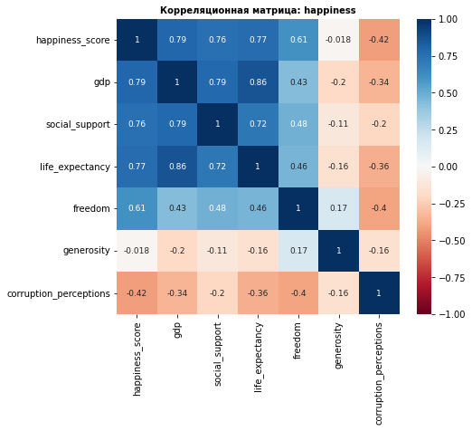

```python
fig = plt.figure(figsize=(7,6))

ax = sns.heatmap(happiness.select_dtypes(include='number').corr(),
            vmin=-1, vmax=1, cmap='RdBu',
            annot = True,
            annot_kws={"fontsize":9})
plt.xticks(fontsize=10)
plt.yticks(fontsize=10)
cbar = ax.collections[0].colorbar
cbar.ax.tick_params(labelsize=10)
plt.title('Корреляционная матрица: happiness', fontsize=10, fontweight='bold')


plt.show()
```

Как мы можем заметить, на уровень счастья в стране влияют высокий показатель ВВП (т.е. развитая экономика), высокая социальная поддержка (пенсии, стипендии, хорошее медобслуживание и прочее), уровень свободы, однако очень много людей беспокоит уровень коррупции, что снижает уровень счастья.

```python
from statsmodels.stats.outliers_influence import variance_inflation_factor
from statsmodels.tools.tools import add_constant

X = add_constant(sleep)
VIFs = pd.DataFrame()
VIFs['Variable'] = X.columns
VIFs['VIF'] = [variance_inflation_factor(X.values, i) for i in range(X.shape[1])]
print(VIFs)
```

```
               Variable          VIF
0                 const  5532.834459
1  HeartRateVariability     1.007842
2       BodyTemperature     1.008690
3   MovementDuringSleep     1.013106
4    SleepDurationHours     1.015123
5     SleepQualityScore     2.139904
6      CaffeineIntakeMg     2.118646
7           StressLevel     1.004118
8    BedtimeConsistency     1.014450
9    LightExposureHours     1.001291
```

Высокие значения VIF указывают на потенциальные проблемы с мультиколлинеарностью. Как правило, значение VIF выше 5 требует внимания, а выше 10 — серьезного рассмотрения изменений в модели. У нас все в порядке.

```python
X = add_constant(happiness.select_dtypes(include='number'))
VIFs = pd.DataFrame()
VIFs['Variable'] = X.columns
VIFs['VIF'] = [variance_inflation_factor(X.values, i) for i in range(X.shape[1])]
print(VIFs)
```

```
                 Variable         VIF
0                   const  219.715655
1         happiness_score    4.095795
2                     gdp    5.477390
3          social_support    3.259623
4         life_expectancy    4.248569
5                 freedom    1.770176
6              generosity    1.191685
7  corruption_perceptions    1.408890
```

```python
X = add_constant(happiness.select_dtypes(include='number').drop(['gdp'], axis=1))
VIFs = pd.DataFrame()
VIFs['Variable'] = X.columns
VIFs['VIF'] = [variance_inflation_factor(X.values, i) for i in range(X.shape[1])]
print(VIFs)
```

```
                 Variable         VIF
0                   const  213.374298
1         happiness_score    3.817253
2          social_support    2.837053
3         life_expectancy    2.963900
4                 freedom    1.742486
5              generosity    1.154653
6  corruption_perceptions    1.391416
```

# 12. Исследовать зависимости в данных с помощью дисперсионного анализа

**Дисперсионный анализ (ANOVA)** — это статистический метод, который используется для сравнения средних значений двух или более выборок. Он позволяет определить, различаются ли средние значения между группами, или же различия случайны.

#### 1. Однофакторный дисперсионный анализ

Однофакторный ANOVA (однофакторный дисперсионный анализ) – это метод статистического анализа данных, который используется для определения наличия статистически значимых различий между двумя или более группами по одной независимой переменной.

Пусть A - категориальная переменная (фактор) с k уровнями и пусть $x^1 = (x_{11}, \dots, x_{1n}), ..., x^k = (x_{k1}, \dots, x_{kn})$ - подвыборки выборки $x$, $\mu_1, \dots, \mu_k$ - математические ожидания подвыборок.

Нулевая гипотеза $H_0: \mu_1 = \mu_2 = \dots = \mu_k$

Альтернативная гипотеза: не все средние равны.

Дополнительные предположения для однофакторного ANOVA:

1. Независимость наблюдений: Данные в каждой группе должны быть независимыми друг от друга.
2. Нормальность распределения: Распределение зависимой переменной в каждой группе должно быть близким к нормальному.
3. Гомогенность дисперсий: Дисперсии зависимой переменной в разных группах должны быть примерно равными.

Вспомним, что в датасете `happiness` есть нормально распределенная выборка `happiness_score` (это так, поскольку тест Шапиро-Уилка выдает `p-value > 0.05`). Предполагаем, что результаты тестирования стран на уровень счастья независимые.

```python
shapiro(happiness['happiness_score'])
```

```
ShapiroResult(statistic=0.9912537209520474, pvalue=0.4893410649623995)
```

Для определения гомогенности дисперсий вначале обратимся к `stripchart` уровня счастья в зависимости от региона.

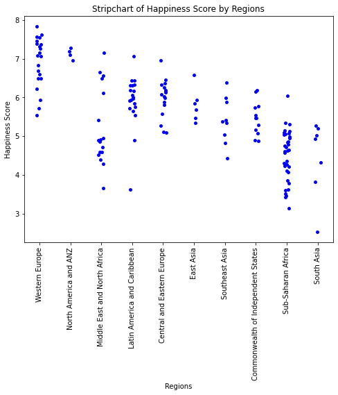

```python
plt.figure(figsize=(8, 6))
sns.stripplot(data=happiness, x='region', y='happiness_score', jitter=True, color='blue')
plt.xticks(rotation=90)
plt.xlabel('Regions')
plt.ylabel('Happiness Score')
plt.title('Stripchart of Happiness Score by Regions')
plt.show()
```

Заметим, что регионы `Latin America and Caribbean`, `Sub-Saharan Africa`, `Middle East and North Africa` сильно выделяются на фоне других по дисперсии. Проведем тест Левене для них.

```python
middle_east = happiness['happiness_score'][happiness.region == 'Middle East and North Africa']
latin = happiness['happiness_score'][happiness.region == 'Latin America and Caribbean']
sahara = happiness['happiness_score'][happiness.region == 'Sub-Saharan Africa']
print(middle_east.std(), latin.std(), sahara.std())
```

```
0.9992591961930951 0.69346691758834 0.654891986126005
```

```python
stats.levene(middle_east, latin, sahara, center='median')
```

```
LeveneResult(statistic=1.7279520537516624, pvalue=0.1851384416472439)
```

`p-value > 0.05`, поэтому можем принять гипотезу о равенстве дисперсий. One-Way ANOVA применим.

```python
from scipy import stats
f_stat, p_value = stats.f_oneway(middle_east, latin, sahara)
print(f'F-статистика: {f_stat}, p-значение: {p_value}')
```

```
F-статистика: 22.962959574332046, p-значение: 2.1483855397171614e-08
```

Мы не можем принять гипотезу о равенстве средних, значит, регион проживания действительно влияет на уровень счастья.

#### 2. Многофакторный дисперсионный анализ

Теперь исследуем влияние нескольких факторов на уровень счастья. Создадим новую факторную переменную `freedom_level`, основанную на `freedom`.

```python
happiness['freedom_level'] = pd.cut(happiness['freedom'],
                                   bins=[-1, 0.7, 0.85, 1],
                                   labels=['Low', 'Medium', 'High'],
                                   right=True)
```

```python
sub_happiness = happiness[happiness['region'].isin(['Middle East and North Africa', 'Latin America and Caribbean', 'Sub-Saharan Africa'])]
sub_happiness
```

|  | Country name | region | happiness_score | gdp | social_support | life_expectancy | freedom | generosity | corruption_perceptions | freedom_level |
| --- | --- | --- | --- | --- | --- | --- | --- | --- | --- | --- |
| 11 | Israel | Middle East and North Africa | 7.157 | 10.575 | 0.939 | 73.503 | 0.800 | 0.031 | 0.753 | Medium |
| 15 | Costa Rica | Latin America and Caribbean | 7.069 | 9.880 | 0.891 | 71.400 | 0.934 | -0.126 | 0.809 | High |
| 21 | Bahrain | Middle East and North Africa | 6.647 | 10.669 | 0.862 | 69.495 | 0.925 | 0.089 | 0.722 | High |
| 24 | United Arab Emirates | Middle East and North Africa | 6.561 | 11.085 | 0.844 | 67.333 | 0.932 | 0.074 | 0.589 | High |
| 25 | Saudi Arabia | Middle East and North Africa | 6.494 | 10.743 | 0.891 | 66.603 | 0.877 | -0.149 | 0.684 | High |
| ... | ... | ... | ... | ... | ... | ... | ... | ... | ... | ... |
| 143 | Malawi | Sub-Saharan Africa | 3.600 | 6.958 | 0.537 | 57.948 | 0.780 | 0.038 | 0.729 | Medium |
| 144 | Lesotho | Sub-Saharan Africa | 3.512 | 7.926 | 0.787 | 48.700 | 0.715 | -0.131 | 0.915 | Medium |
| 145 | Botswana | Sub-Saharan Africa | 3.467 | 9.782 | 0.784 | 59.269 | 0.824 | -0.246 | 0.801 | Medium |
| 146 | Rwanda | Sub-Saharan Africa | 3.415 | 7.676 | 0.552 | 61.400 | 0.897 | 0.061 | 0.167 | High |
| 147 | Zimbabwe | Sub-Saharan Africa | 3.145 | 7.943 | 0.750 | 56.201 | 0.677 | -0.047 | 0.821 | Low |

73 rows × 10 columns

```python
import statsmodels.api as sm
from statsmodels.formula.api import ols

model = ols('happiness_score ~ freedom_level * region', data=sub_happiness).fit()
anova_table = sm.stats.anova_lm(model, typ=2)
anova_table
```

|  | sum_sq | df | F | PR(>F) |
| --- | --- | --- | --- | --- |
| freedom_level | 8.830030 | 2.0 | 11.514710 | 0.000054 |
| region | 11.585382 | 2.0 | 15.107799 | 0.000004 |
| freedom_level:region | 6.755099 | 4.0 | 4.404459 | 0.003301 |
| Residual | 24.539128 | 64.0 | NaN | NaN |

Вышеперечисленные факторы и их сочетания влияют на уровень счастья.

# 13. Подогнать регрессионные модели (в том числе, нелинейные) к данным, а также оценить качество подобной аппроксимации.

#### 1. Линейная регрессия на объединенных данных за 2021 и 2023 годы.

```python
sub_happiness = happiness[['happiness_score', 'gdp', 'social_support', 'life_expectancy','freedom',	'generosity']]
sub_happiness2023 = happiness2023[['happiness_score', 'gdp', 'social_support', 'life_expectancy','freedom', 'generosity']]
happiness_combined = pd.concat([sub_happiness, sub_happiness2023], axis=0, ignore_index=True)
happiness_combined = happiness_combined.fillna(happiness_combined.median())
```

```python
import statsmodels.api as sm

X, y = happiness_combined.select_dtypes('number').drop(['happiness_score'], axis=1), happiness_combined['happiness_score']
X = sm.add_constant(X)
model = sm.OLS(y, X).fit()
model.summary()
```

OLS Regression Results

| Dep. Variable: | happiness_score | R-squared: | 0.780 |
| --- | --- | --- | --- |
| Model: | OLS | Adj. R-squared: | 0.776 |
| Method: | Least Squares | F-statistic: | 198.3 |
| Date: | Sat, 07 Dec 2024 | Prob (F-statistic): | 8.55e-90 |
| Time: | 13:19:18 | Log-Likelihood: | -217.24 |
| No. Observations: | 286 | AIC: | 446.5 |
| Df Residuals: | 280 | BIC: | 468.4 |
| Df Model: | 5 |  |  |
| Covariance Type: | nonrobust |  |  |

|  | coef | std err | t | P>\|t\| | [0.025 | 0.975] |
| --- | --- | --- | --- | --- | --- | --- |
| const | -3.3409 | 0.342 | -9.777 | 0.000 | -4.014 | -2.668 |
| gdp | 0.2849 | 0.054 | 5.244 | 0.000 | 0.178 | 0.392 |
| social_support | 2.8889 | 0.416 | 6.938 | 0.000 | 2.069 | 3.709 |
| life_expectancy | 0.0292 | 0.009 | 3.081 | 0.002 | 0.011 | 0.048 |
| freedom | 2.4813 | 0.333 | 7.451 | 0.000 | 1.826 | 3.137 |
| generosity | 0.4784 | 0.223 | 2.149 | 0.033 | 0.040 | 0.917 |

| Omnibus: | 17.020 | Durbin-Watson: | 1.761 |
| --- | --- | --- | --- |
| Prob(Omnibus): | 0.000 | Jarque-Bera (JB): | 18.755 |
| Skew: | -0.551 | Prob(JB): | 8.46e-05 |
| Kurtosis: | 3.600 | Cond. No. | 959. |

Notes:  
[1] Standard Errors assume that the covariance matrix of the errors is correctly specified.

```python
y_pred = model.fittedvalues
y_true = y
mse = np.mean((y_true - y_pred) ** 2)
rmse = np.sqrt(mse)

print(f"MSE: {mse}")
print(f"RMSE: {rmse}")
```

```
MSE: 0.2674735568174922
RMSE: 0.5171784574182225
```

Итак, уравнение регрессии имеет вид: $$ HappinessScore = -3.3409 + 0.2849 \cdot GDP + 2.8889 \cdot socialSupport + 0.0292 \cdot lifeExpectancy + 2.4813 \cdot freedom + 0.4784 \cdot generosity$$

```python
import statsmodels.formula.api as smf

model_1 = smf.ols(formula='happiness_score ~ gdp', data=happiness_combined).fit()
print(model_1.summary())

y_pred = model_1.fittedvalues
y_true = y
mse = np.mean((y_true - y_pred) ** 2)
rmse = np.sqrt(mse)

print(f"MSE: {mse}")
print(f"RMSE: {rmse}")
```

```
                            OLS Regression Results
==============================================================================
Dep. Variable:        happiness_score   R-squared:                       0.619
Model:                            OLS   Adj. R-squared:                  0.618
Method:                 Least Squares   F-statistic:                     462.1
Date:                Sat, 07 Dec 2024   Prob (F-statistic):           1.61e-61
Time:                        13:41:05   Log-Likelihood:                -295.50
No. Observations:                 286   AIC:                             595.0
Df Residuals:                     284   BIC:                             602.3
Df Model:                           1
Covariance Type:            nonrobust
==============================================================================
                 coef    std err          t      P>|t|      [0.025      0.975]
------------------------------------------------------------------------------
Intercept     -1.4149      0.326     -4.342      0.000      -2.056      -0.774
gdp            0.7363      0.034     21.498      0.000       0.669       0.804
==============================================================================
Omnibus:                       32.822   Durbin-Watson:                   1.342
Prob(Omnibus):                  0.000   Jarque-Bera (JB):               71.197
Skew:                          -0.580   Prob(JB):                     3.47e-16
Kurtosis:                       5.151   Cond. No.                         77.7
==============================================================================

Notes:
[1] Standard Errors assume that the covariance matrix of the errors is correctly specified.
MSE: 0.46235870247612226
RMSE: 0.6799696334955865
```

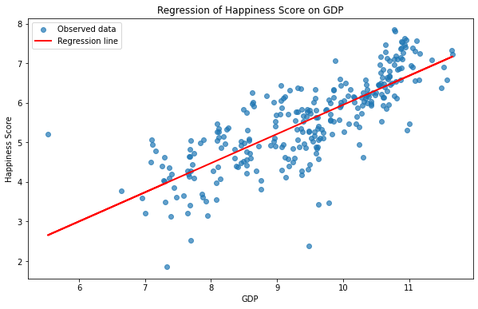

```python
import numpy as np
import matplotlib.pyplot as plt

pred = model_1.predict(happiness_combined[['gdp']])
plt.figure(figsize=(10, 6))
plt.scatter(happiness_combined['gdp'], happiness_combined['happiness_score'], label="Observed data", alpha=0.7)
plt.plot(happiness_combined['gdp'], pred, color='red', label="Regression line", linewidth=2)
plt.title("Regression of Happiness Score on GDP")
plt.xlabel("GDP")
plt.ylabel("Happiness Score")
plt.legend()
plt.show()
```

#### 2. Полиномиальная регрессия на объединенных данных за 2021 и 2023 годы.

```python
from sklearn.preprocessing import PolynomialFeatures

X, y = happiness_combined.select_dtypes('number').drop(['happiness_score'], axis=1), happiness_combined['happiness_score']

degree = 2
poly = PolynomialFeatures(degree, include_bias=False)
X_poly = poly.fit_transform(X)

columns = poly.get_feature_names_out(X.columns)
X_poly_df = pd.DataFrame(X_poly, columns=columns)
X_poly_df['y'] = y

X_poly_sm = sm.add_constant(X_poly_df.drop(['y'], axis=1))
model = sm.OLS(X_poly_df['y'], X_poly_sm).fit()

print(model.summary())

y_pred = model.fittedvalues
y_true = y
mse = np.mean((y_true - y_pred) ** 2)
rmse = np.sqrt(mse)
print(f"MSE: {mse}")
print(f"RMSE: {rmse}")
```

```
                            OLS Regression Results
==============================================================================
Dep. Variable:                      y   R-squared:                       0.839
Model:                            OLS   Adj. R-squared:                  0.827
Method:                 Least Squares   F-statistic:                     68.93
Date:                Sat, 07 Dec 2024   Prob (F-statistic):           9.69e-93
Time:                        13:19:47   Log-Likelihood:                -172.66
No. Observations:                 286   AIC:                             387.3
Df Residuals:                     265   BIC:                             464.1
Df Model:                          20
Covariance Type:            nonrobust
==================================================================================================
                                     coef    std err          t      P>|t|      [0.025      0.975]
--------------------------------------------------------------------------------------------------
const                              9.7820      3.098      3.158      0.002       3.683      15.882
gdp                                0.6213      0.621      1.000      0.318      -0.602       1.845
social_support                   -20.4444      4.722     -4.329      0.000     -29.742     -11.147
life_expectancy                   -0.1556      0.109     -1.427      0.155      -0.370       0.059
freedom                            4.2143      4.270      0.987      0.325      -4.194      12.622
generosity                         6.2661      2.942      2.130      0.034       0.474      12.059
gdp^2                              0.1181      0.044      2.679      0.008       0.031       0.205
gdp social_support                -0.3481      0.718     -0.485      0.628      -1.762       1.066
gdp life_expectancy               -0.0270      0.016     -1.695      0.091      -0.058       0.004
gdp freedom                       -0.5845      0.650     -0.899      0.369      -1.865       0.696
gdp generosity                     1.0782      0.472      2.284      0.023       0.149       2.007
social_support^2                  -7.8351      3.511     -2.231      0.026     -14.749      -0.921
social_support life_expectancy     0.6225      0.113      5.518      0.000       0.400       0.845
social_support freedom            -0.7173      3.766     -0.190      0.849      -8.133       6.699
social_support generosity          7.6585      3.280      2.335      0.020       1.201      14.116
life_expectancy^2                 -0.0012      0.002     -0.687      0.492      -0.005       0.002
life_expectancy freedom            0.1121      0.121      0.929      0.354      -0.125       0.350
life_expectancy generosity        -0.2726      0.077     -3.522      0.001      -0.425      -0.120
freedom^2                         -2.3303      2.537     -0.919      0.359      -7.325       2.664
freedom generosity                -5.5541      2.727     -2.037      0.043     -10.924      -0.185
generosity^2                      -2.0095      1.074     -1.871      0.062      -4.124       0.105
==============================================================================
Omnibus:                       18.992   Durbin-Watson:                   1.792
Prob(Omnibus):                  0.000   Jarque-Bera (JB):               20.826
Skew:                          -0.622   Prob(JB):                     3.00e-05
Kurtosis:                       3.446   Cond. No.                     9.77e+05
==============================================================================

Notes:
[1] Standard Errors assume that the covariance matrix of the errors is correctly specified.
[2] The condition number is large, 9.77e+05. This might indicate that there are
strong multicollinearity or other numerical problems.
MSE: 0.19584377201195174
RMSE: 0.4425423957226604
```

```python
import statsmodels.formula.api as smf

model_poly = smf.ols(formula='happiness_score ~ gdp + I(gdp**2)', data=happiness_combined).fit()
print(model_poly.summary())

y_pred = model_poly.fittedvalues
y_true = y
mse = np.mean((y_true - y_pred) ** 2)
rmse = np.sqrt(mse)
print(f"MSE: {mse}")
print(f"RMSE: {rmse}")
```

```
                            OLS Regression Results
==============================================================================
Dep. Variable:        happiness_score   R-squared:                       0.642
Model:                            OLS   Adj. R-squared:                  0.640
Method:                 Least Squares   F-statistic:                     254.3
Date:                Sat, 07 Dec 2024   Prob (F-statistic):           6.26e-64
Time:                        14:05:35   Log-Likelihood:                -286.56
No. Observations:                 286   AIC:                             579.1
Df Residuals:                     283   BIC:                             590.1
Df Model:                           2
Covariance Type:            nonrobust
===============================================================================
                  coef    std err          t      P>|t|      [0.025      0.975]
-------------------------------------------------------------------------------
Intercept       7.5689      2.126      3.560      0.000       3.384      11.753
gdp            -1.2518      0.466     -2.684      0.008      -2.170      -0.334
I(gdp ** 2)     0.1081      0.025      4.274      0.000       0.058       0.158
==============================================================================
Omnibus:                       36.752   Durbin-Watson:                   1.270
Prob(Omnibus):                  0.000   Jarque-Bera (JB):               63.679
Skew:                          -0.732   Prob(JB):                     1.49e-14
Kurtosis:                       4.788   Cond. No.                     5.20e+03
==============================================================================

Notes:
[1] Standard Errors assume that the covariance matrix of the errors is correctly specified.
[2] The condition number is large, 5.2e+03. This might indicate that there are
strong multicollinearity or other numerical problems.
MSE: 0.4343300642596425
RMSE: 0.659037225245769
```

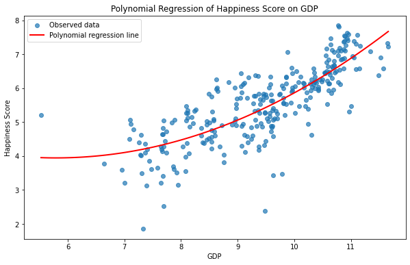

```python
gdp_sorted = np.linspace(happiness_combined['gdp'].min(), happiness_combined['gdp'].max(), 100)
predicted_happiness = model_poly.predict({'gdp': gdp_sorted})

plt.figure(figsize=(10, 6))
plt.scatter(happiness_combined['gdp'], happiness_combined['happiness_score'], label="Observed data", alpha=0.7)
plt.plot(gdp_sorted, predicted_happiness, color='red', label="Polynomial regression line", linewidth=2)
plt.title("Polynomial Regression of Happiness Score on GDP")
plt.xlabel("GDP")
plt.ylabel("Happiness Score")
plt.legend()
plt.show()
```

#### 3. Логарифмическая регрессия на объединенных данных за 2021 и 2023 годы.

```python
X, y = happiness_combined.select_dtypes('number').drop(['happiness_score'], axis=1), happiness_combined['happiness_score']
X_log = X.copy()
X_log = np.log1p(X_log)

X_log = sm.add_constant(X_log)
model_log = sm.OLS(y, X_log).fit()
print(model_log.summary())
y_pred = model_log.fittedvalues
y_true = y
mse = np.mean((y_true - y_pred) ** 2)
rmse = np.sqrt(mse)
print(f"MSE: {mse}")
print(f"RMSE: {rmse}")
```

```
                            OLS Regression Results
==============================================================================
Dep. Variable:        happiness_score   R-squared:                       0.771
Model:                            OLS   Adj. R-squared:                  0.767
Method:                 Least Squares   F-statistic:                     189.0
Date:                Sat, 07 Dec 2024   Prob (F-statistic):           1.59e-87
Time:                        14:12:53   Log-Likelihood:                -222.59
No. Observations:                 286   AIC:                             457.2
Df Residuals:                     280   BIC:                             479.1
Df Model:                           5
Covariance Type:            nonrobust
===================================================================================
                      coef    std err          t      P>|t|      [0.025      0.975]
-----------------------------------------------------------------------------------
const             -14.8488      1.753     -8.469      0.000     -18.300     -11.397
gdp                 2.7811      0.538      5.172      0.000       1.723       3.840
social_support      4.9545      0.728      6.805      0.000       3.521       6.388
life_expectancy     2.0335      0.597      3.407      0.001       0.859       3.208
freedom             4.2328      0.590      7.177      0.000       3.072       5.394
generosity          0.6212      0.236      2.634      0.009       0.157       1.085
==============================================================================
Omnibus:                       14.871   Durbin-Watson:                   1.757
Prob(Omnibus):                  0.001   Jarque-Bera (JB):               15.883
Skew:                          -0.518   Prob(JB):                     0.000356
Kurtosis:                       3.508   Cond. No.                         294.
==============================================================================

Notes:
[1] Standard Errors assume that the covariance matrix of the errors is correctly specified.
MSE: 0.2776784431095363
RMSE: 0.5269520311276316
```

```python
import statsmodels.formula.api as smf
import numpy as np

model_log = smf.ols(formula='happiness_score ~ np.log(gdp)', data=happiness_combined).fit()
print(model_log.summary())
y_pred = model_log.fittedvalues
y_true = y
mse = np.mean((y_true - y_pred) ** 2)
rmse = np.sqrt(mse)
print(f"MSE: {mse}")
print(f"RMSE: {rmse}")
```

```
                            OLS Regression Results
==============================================================================
Dep. Variable:        happiness_score   R-squared:                       0.597
Model:                            OLS   Adj. R-squared:                  0.595
Method:                 Least Squares   F-statistic:                     420.0
Date:                Sat, 07 Dec 2024   Prob (F-statistic):           6.39e-58
Time:                        14:19:34   Log-Likelihood:                -303.83
No. Observations:                 286   AIC:                             611.7
Df Residuals:                     284   BIC:                             619.0
Df Model:                           1
Covariance Type:            nonrobust
===============================================================================
                  coef    std err          t      P>|t|      [0.025      0.975]
-------------------------------------------------------------------------------
Intercept      -9.0838      0.715    -12.711      0.000     -10.490      -7.677
np.log(gdp)     6.5361      0.319     20.493      0.000       5.908       7.164
==============================================================================
Omnibus:                       30.264   Durbin-Watson:                   1.325
Prob(Omnibus):                  0.000   Jarque-Bera (JB):               87.398
Skew:                          -0.429   Prob(JB):                     1.05e-19
Kurtosis:                       5.568   Cond. No.                         46.2
==============================================================================

Notes:
[1] Standard Errors assume that the covariance matrix of the errors is correctly specified.
MSE: 0.4900669636222913
RMSE: 0.7000478295247342
```

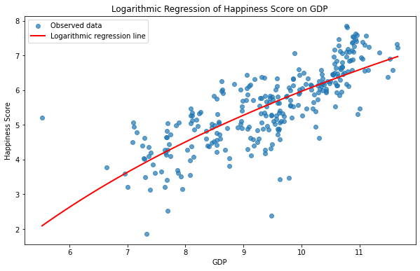

```python
import matplotlib.pyplot as plt
gdp_sorted = np.linspace(happiness_combined['gdp'].min(), happiness_combined['gdp'].max(), 100)
predicted_happiness = model_log.predict({'gdp': gdp_sorted})
plt.figure(figsize=(10, 6))
plt.scatter(happiness_combined['gdp'], happiness_combined['happiness_score'], label="Observed data", alpha=0.7)
plt.plot(gdp_sorted, predicted_happiness, color='red', label="Logarithmic regression line", linewidth=2)
plt.title("Logarithmic Regression of Happiness Score on GDP")
plt.xlabel("GDP")
plt.ylabel("Happiness Score")
plt.legend()
plt.show()
```